# NDVI (versão 1)

Igor Viana Souza

14/12/2021

### 1. Introdução

O documento tem como propósito auxiliar no entendimento do *script* na geração de imagens NDVIs e RGBs. A sua principal função é automatizar alguns processos repetitivos durante a geração dos produtos, tais como: leitura de arquivos, recortes, cálculo do NDVI e exportação dos produtos gerados.

### 2. Importação das bibliotecas

Os pacotes são conjunto de funções que nos auxiliarão a desenvolver um determinado resultado. Boa parte desses pacotes podem ser encontrados na base oficial do *R (CRAN)*. Antes de importar as bibliotecas, é importante realizamos uma limpeza na mémoria do R.

```r
#Limpar memória
rm(list=ls(all=TRUE))
```

```r
# Importando pacotes
library(raster)
library(rgdal)
```

### 4. Criando uma lista para armazenar nossos arquivos

Dentro da pasta R criada anteriormente, crie uma pasta chamada RGB, NDVI e TALHAO. Em cada pasta, você deverá colocar as imagens selecionadas e o poligono. Ao executar as linhas abaixo, é observado o que contém armazenado em lista em cada pasta.

```r
RGB <- list.files(path="RGB", pattern = ".tif", full.names = TRUE)
SHP <- list.files(path="TALHAO", pattern = ".shp", full.names = TRUE)
INDICE <- list.files(path="NDVI", pattern = ".tif", full.names = TRUE)

RGB
```

```
## [1] "RGB/S2B_MSIL2A_20220216T133219_N0400_R081_T22KEG_20220216T164142_TCI.tif"
```

```r
SHP
```

```
## [1] "TALHAO/co_1.shp"
```

```r
INDICE
```

```
## [1] "NDVI/S2B_MSIL2A_20220216T133219_N0400_R081_T22KEG_20220216T164142_r8g11b4.tif"
```

### 5. Lendo os arquivos em suas respectivas Pastas

#### 5.1 RGB

A executar, todas as imagens da pasta são carregadas para a memória com o repectivos nomes.

```r
## Criando um lista vazia para as Imagens RGB

RGB_STACK<-c()
```

```r
## Leitura de todas imagens na Pasta RGB

r_name <- list.files(path="RGB",full.names = F)

for(i in RGB){ RGB_STACK[[i]]<- stack(i)}

names(RGB_STACK)<- c(r_name)

RGB_STACK
```

```
## $S2B_MSIL2A_20220216T133219_N0400_R081_T22KEG_20220216T164142_TCI.tif
## class      : RasterStack
## dimensions : 390, 468, 182520, 3  (nrow, ncol, ncell, nlayers)
## resolution : 8.983153e-05, 8.983153e-05  (x, y)
## extent     : -50.29694, -50.2549, -17.25951, -17.22448  (xmin, xmax, ymin, ymax)
## crs        : +proj=longlat +datum=WGS84 +no_defs
## names      : TCI_R, TCI_G, TCI_B
## min values :     0,     0,     0
## max values :   255,   255,   255
```

#### 5.2 NDVI

```r
NDVI_STACK<-c()

r_name1 <- list.files(path="NDVI",full.names = F)

for(g in INDICE){
  NDVI_STACK[[g]]<- stack(g)}


names(NDVI_STACK)<- c(r_name1)

NDVI_STACK
```

```
## $S2B_MSIL2A_20220216T133219_N0400_R081_T22KEG_20220216T164142_r8g11b4.tif
## class      : RasterStack
## dimensions : 390, 468, 182520, 3  (nrow, ncol, ncell, nlayers)
## resolution : 8.983153e-05, 8.983153e-05  (x, y)
## extent     : -50.29694, -50.2549, -17.25951, -17.22448  (xmin, xmax, ymin, ymax)
## crs        : +proj=longlat +datum=WGS84 +no_defs
## names      :    B8,   B11,    B4
## min values :     0,     0,     0
## max values : 65535, 65535, 65535
```

```r
bandas<-NDVI_STACK[[1]]
```

#### 5.3 TALHAO

```r
TALHAO<-c()
for(j in SHP){TALHAO[[j]]<- sf::st_read(j)}
```

### 6. Cálculo do Índice de Diferença Normalizada Para Sentinel (NDVI)

Os números em `sat_ndvi <- (bandas[[1]] - bandas[[3]]) / (bandas[[1]] + bandas[[3]])` corresponde a ordem em que a banda espectral encontra-se na imagem. Logo, o número 1 corresponde a Banda B8 ( Infravermelho próximo) e 3 ( vermelho). o Resultado da expressão matemática, é um índice que varia de -1 a +1.

```r
sat_ndvi_list<-list() ## Criando uma lista para armazenar o produto dos cálculos

sat_ndvi <- (bandas[[1]] - bandas[[3]]) / (bandas[[1]] + bandas[[3]])

NDVI_STACK<- stack(sat_ndvi)

NDVI_STACK
```

```
## class      : RasterStack
## dimensions : 390, 468, 182520, 1  (nrow, ncol, ncell, nlayers)
## resolution : 8.983153e-05, 8.983153e-05  (x, y)
## extent     : -50.29694, -50.2549, -17.25951, -17.22448  (xmin, xmax, ymin, ymax)
## crs        : +proj=longlat +datum=WGS84 +no_defs
## names      :      layer
## min values : -0.1334746
## max values :  0.6812573
```

#### Visualização NDVI

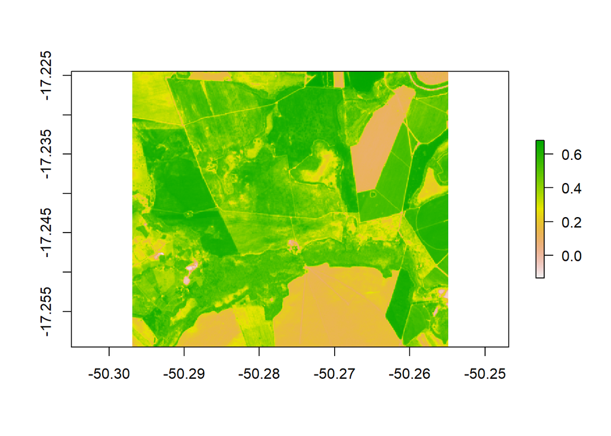

```r
plot(sat_ndvi)
```

### 7. Recortes das imagens por talhão.

Após carregar as imagens RGB e a realização do cálculo NDVI. Necessitamos exportar nosso produto final por talhão, com o propósito de realizarmos posteriormente nossa classificação das cores no Qgis. Neste momento é importante a alteração em `dataoutput<-data.frame(data=r_name[1])`, para o número corresponde a imagem que você está utilizando, nesse caso [1]. Esse momento é de extrema importancia, pois a partir desse momento, conseguimos criar um forma pra nomear os arquivos de saída conforme a data da imagem e o talhão.

```r
CO<-TALHAO[[1]]

TA<-CO$TALHAO

output <- data.frame(t = TA)


dataoutput<-data.frame(data=r_name[1]) ##ALTERA O NÚMERO, PARA MUDAR A IMAGEM

output
```

```
##     t
## 1 G_2
## 2 G_3
## 3 G_4
## 4 G_5
## 5 G_1
## 6 G_4
## 7 G_2
## 8 G_3
## 9 G_5
```

```r
dataoutput
```

```
##                                                                   data
## 1 S2B_MSIL2A_20220216T133219_N0400_R081_T22KEG_20220216T164142_TCI.tif
```

```r
names_data<-paste("RGB_",output$t,dataoutput$data)

LISTA<-list()
```

#### 7.1 Recorte RGB

Mais uma vez precisamos alterar a númeração de `RGB_STACK[[1]]`. Nesse momento é realizado os corte por talhão, sendo armazendo em uma lista `LISTA<-list()` .

```r
RGB_STACK
```

```
## $S2B_MSIL2A_20220216T133219_N0400_R081_T22KEG_20220216T164142_TCI.tif
## class      : RasterStack
## dimensions : 390, 468, 182520, 3  (nrow, ncol, ncell, nlayers)
## resolution : 8.983153e-05, 8.983153e-05  (x, y)
## extent     : -50.29694, -50.2549, -17.25951, -17.22448  (xmin, xmax, ymin, ymax)
## crs        : +proj=longlat +datum=WGS84 +no_defs
## names      : TCI_R, TCI_G, TCI_B
## min values :     0,     0,     0
## max values :   255,   255,   255
```

```r
for (c in 1:length(output$t)) {LISTA[c]<- mask(RGB_STACK[[1]], CO[CO$TALHAO==output$t[c],])

}
```

[output not shown]

```r
 names(LISTA)<- c(names_data)
 LISTA
```

```
## $`RGB_ G_2 S2B_MSIL2A_20220216T133219_N0400_R081_T22KEG_20220216T164142_TCI.tif`
## class      : RasterBrick
## dimensions : 390, 468, 182520, 3  (nrow, ncol, ncell, nlayers)
## resolution : 8.983153e-05, 8.983153e-05  (x, y)
## extent     : -50.29694, -50.2549, -17.25951, -17.22448  (xmin, xmax, ymin, ymax)
## crs        : +proj=longlat +datum=WGS84 +no_defs
## source     : memory
## names      : TCI_R, TCI_G, TCI_B
## min values :    41,    57,    39
## max values :   255,   255,   255
##
##
## $`RGB_ G_3 S2B_MSIL2A_20220216T133219_N0400_R081_T22KEG_20220216T164142_TCI.tif`
## class      : RasterBrick
## dimensions : 390, 468, 182520, 3  (nrow, ncol, ncell, nlayers)
## resolution : 8.983153e-05, 8.983153e-05  (x, y)
## extent     : -50.29694, -50.2549, -17.25951, -17.22448  (xmin, xmax, ymin, ymax)
## crs        : +proj=longlat +datum=WGS84 +no_defs
## source     : memory
## names      : TCI_R, TCI_G, TCI_B
## min values :    29,    54,    33
## max values :   130,   129,    73
##
##
## $`RGB_ G_4 S2B_MSIL2A_20220216T133219_N0400_R081_T22KEG_20220216T164142_TCI.tif`
## class      : RasterBrick
## dimensions : 390, 468, 182520, 3  (nrow, ncol, ncell, nlayers)
## resolution : 8.983153e-05, 8.983153e-05  (x, y)
## extent     : -50.29694, -50.2549, -17.25951, -17.22448  (xmin, xmax, ymin, ymax)
## crs        : +proj=longlat +datum=WGS84 +no_defs
## source     : memory
## names      : TCI_R, TCI_G, TCI_B
## min values :    28,    54,    33
## max values :   148,   127,    74
##
##
## $`RGB_ G_5 S2B_MSIL2A_20220216T133219_N0400_R081_T22KEG_20220216T164142_TCI.tif`
## class      : RasterBrick
## dimensions : 390, 468, 182520, 3  (nrow, ncol, ncell, nlayers)
## resolution : 8.983153e-05, 8.983153e-05  (x, y)
```

[output cut: 51 more lines]

```
## names      : TCI_R, TCI_G, TCI_B
## min values :    29,    54,    33
## max values :   130,   129,    73
##
##
## $`RGB_ G_5 S2B_MSIL2A_20220216T133219_N0400_R081_T22KEG_20220216T164142_TCI.tif`
## class      : RasterBrick
## dimensions : 390, 468, 182520, 3  (nrow, ncol, ncell, nlayers)
## resolution : 8.983153e-05, 8.983153e-05  (x, y)
## extent     : -50.29694, -50.2549, -17.25951, -17.22448  (xmin, xmax, ymin, ymax)
## crs        : +proj=longlat +datum=WGS84 +no_defs
## source     : memory
## names      : TCI_R, TCI_G, TCI_B
## min values :    25,    48,    30
## max values :   108,    87,    63
```

Apesar das várias mensagens de “Warning in”(Somente um alerta), O processo foi executado com sucesso.

#### 7.2 Recorte NDVI

Agora repetindo mesmo procedimento para o NDVI.

```r
LISTA_NDVI<-list()

for (y in 1:length(output$t)) {LISTA_NDVI[y]<- mask(sat_ndvi, CO[CO$TALHAO==output$t[y],])
}
```

[output not shown]

```r
names_data2<-paste("NDVI_",output$t,dataoutput$data)
names(LISTA_NDVI)<- c(names_data2)
LISTA_NDVI
```

```
## $`NDVI_ G_2 S2B_MSIL2A_20220216T133219_N0400_R081_T22KEG_20220216T164142_TCI.tif`
## class      : RasterLayer
## dimensions : 390, 468, 182520  (nrow, ncol, ncell)
## resolution : 8.983153e-05, 8.983153e-05  (x, y)
## extent     : -50.29694, -50.2549, -17.25951, -17.22448  (xmin, xmax, ymin, ymax)
## crs        : +proj=longlat +datum=WGS84 +no_defs
## source     : memory
## names      : layer
## values     : 0.05102954, 0.5903614  (min, max)
##
##
## $`NDVI_ G_3 S2B_MSIL2A_20220216T133219_N0400_R081_T22KEG_20220216T164142_TCI.tif`
## class      : RasterLayer
## dimensions : 390, 468, 182520  (nrow, ncol, ncell)
## resolution : 8.983153e-05, 8.983153e-05  (x, y)
## extent     : -50.29694, -50.2549, -17.25951, -17.22448  (xmin, xmax, ymin, ymax)
## crs        : +proj=longlat +datum=WGS84 +no_defs
## source     : memory
## names      : layer
## values     : 0.1956137, 0.6270208  (min, max)
##
##
## $`NDVI_ G_4 S2B_MSIL2A_20220216T133219_N0400_R081_T22KEG_20220216T164142_TCI.tif`
## class      : RasterLayer
## dimensions : 390, 468, 182520  (nrow, ncol, ncell)
## resolution : 8.983153e-05, 8.983153e-05  (x, y)
## extent     : -50.29694, -50.2549, -17.25951, -17.22448  (xmin, xmax, ymin, ymax)
## crs        : +proj=longlat +datum=WGS84 +no_defs
## source     : memory
## names      : layer
## values     : 0.178557, 0.6248548  (min, max)
##
##
## $`NDVI_ G_5 S2B_MSIL2A_20220216T133219_N0400_R081_T22KEG_20220216T164142_TCI.tif`
## class      : RasterLayer
## dimensions : 390, 468, 182520  (nrow, ncol, ncell)
## resolution : 8.983153e-05, 8.983153e-05  (x, y)
## extent     : -50.29694, -50.2549, -17.25951, -17.22448  (xmin, xmax, ymin, ymax)
## crs        : +proj=longlat +datum=WGS84 +no_defs
## source     : memory
```

[output cut: 42 more lines]

```
## crs        : +proj=longlat +datum=WGS84 +no_defs
## source     : memory
## names      : layer
## values     : 0.1956137, 0.6270208  (min, max)
##
##
## $`NDVI_ G_5 S2B_MSIL2A_20220216T133219_N0400_R081_T22KEG_20220216T164142_TCI.tif`
## class      : RasterLayer
## dimensions : 390, 468, 182520  (nrow, ncol, ncell)
## resolution : 8.983153e-05, 8.983153e-05  (x, y)
## extent     : -50.29694, -50.2549, -17.25951, -17.22448  (xmin, xmax, ymin, ymax)
## crs        : +proj=longlat +datum=WGS84 +no_defs
## source     : memory
## names      : layer
## values     : 0.2152936, 0.6504935  (min, max)
```

### 8. EXPORTANDO PRODUTOS

Por fim, exportaremos nossos produtos

```r
mapply(writeRaster, LISTA, names(LISTA), 'GTiff',overwrite= TRUE)
```

```
## $`RGB_ G_2 S2B_MSIL2A_20220216T133219_N0400_R081_T22KEG_20220216T164142_TCI.tif`
## class      : RasterBrick
## dimensions : 390, 468, 182520, 3  (nrow, ncol, ncell, nlayers)
## resolution : 8.983153e-05, 8.983153e-05  (x, y)
## extent     : -50.29694, -50.2549, -17.25951, -17.22448  (xmin, xmax, ymin, ymax)
## crs        : +proj=longlat +datum=WGS84 +no_defs
## source     : RGB_ G_2 S2B_MSIL2A_20220216T133219_N0400_R081_T22KEG_20220216T164142_TCI.tif
## names      : RGB__G_2_S2B_MSIL2A_20220216T133219_N0400_R081_T22KEG_20220216T164142_TCI.1, RGB__G_2_S2B_MSIL2A_20220216T133219_N0400_R081_T22KEG_20220216T164142_TCI.2, RGB__G_2_S2B_MSIL2A_20220216T133219_N0400_R081_T22KEG_20220216T164142_TCI.3
## min values :                                                                          41,                                                                          57,                                                                          39
## max values :                                                                         255,                                                                         255,                                                                         255
##
##
## $`RGB_ G_3 S2B_MSIL2A_20220216T133219_N0400_R081_T22KEG_20220216T164142_TCI.tif`
## class      : RasterBrick
## dimensions : 390, 468, 182520, 3  (nrow, ncol, ncell, nlayers)
## resolution : 8.983153e-05, 8.983153e-05  (x, y)
## extent     : -50.29694, -50.2549, -17.25951, -17.22448  (xmin, xmax, ymin, ymax)
## crs        : +proj=longlat +datum=WGS84 +no_defs
## source     : RGB_ G_3 S2B_MSIL2A_20220216T133219_N0400_R081_T22KEG_20220216T164142_TCI.tif
## names      : RGB__G_3_S2B_MSIL2A_20220216T133219_N0400_R081_T22KEG_20220216T164142_TCI.1, RGB__G_3_S2B_MSIL2A_20220216T133219_N0400_R081_T22KEG_20220216T164142_TCI.2, RGB__G_3_S2B_MSIL2A_20220216T133219_N0400_R081_T22KEG_20220216T164142_TCI.3
## min values :                                                                          29,                                                                          54,                                                                          33
## max values :                                                                         130,                                                                         129,                                                                          73
##
##
## $`RGB_ G_4 S2B_MSIL2A_20220216T133219_N0400_R081_T22KEG_20220216T164142_TCI.tif`
## class      : RasterBrick
## dimensions : 390, 468, 182520, 3  (nrow, ncol, ncell, nlayers)
## resolution : 8.983153e-05, 8.983153e-05  (x, y)
## extent     : -50.29694, -50.2549, -17.25951, -17.22448  (xmin, xmax, ymin, ymax)
## crs        : +proj=longlat +datum=WGS84 +no_defs
## source     : RGB_ G_4 S2B_MSIL2A_20220216T133219_N0400_R081_T22KEG_20220216T164142_TCI.tif
## names      : RGB__G_4_S2B_MSIL2A_20220216T133219_N0400_R081_T22KEG_20220216T164142_TCI.1, RGB__G_4_S2B_MSIL2A_20220216T133219_N0400_R081_T22KEG_20220216T164142_TCI.2, RGB__G_4_S2B_MSIL2A_20220216T133219_N0400_R081_T22KEG_20220216T164142_TCI.3
## min values :                                                                          28,                                                                          54,                                                                          33
## max values :                                                                         148,                                                                         127,                                                                          74
##
##
## $`RGB_ G_5 S2B_MSIL2A_20220216T133219_N0400_R081_T22KEG_20220216T164142_TCI.tif`
## class      : RasterBrick
## dimensions : 390, 468, 182520, 3  (nrow, ncol, ncell, nlayers)
## resolution : 8.983153e-05, 8.983153e-05  (x, y)
```

[output cut: 51 more lines]

```
## names      : RGB__G_3_S2B_MSIL2A_20220216T133219_N0400_R081_T22KEG_20220216T164142_TCI.1, RGB__G_3_S2B_MSIL2A_20220216T133219_N0400_R081_T22KEG_20220216T164142_TCI.2, RGB__G_3_S2B_MSIL2A_20220216T133219_N0400_R081_T22KEG_20220216T164142_TCI.3
## min values :                                                                          29,                                                                          54,                                                                          33
## max values :                                                                         130,                                                                         129,                                                                          73
##
##
## $`RGB_ G_5 S2B_MSIL2A_20220216T133219_N0400_R081_T22KEG_20220216T164142_TCI.tif`
## class      : RasterBrick
## dimensions : 390, 468, 182520, 3  (nrow, ncol, ncell, nlayers)
## resolution : 8.983153e-05, 8.983153e-05  (x, y)
## extent     : -50.29694, -50.2549, -17.25951, -17.22448  (xmin, xmax, ymin, ymax)
## crs        : +proj=longlat +datum=WGS84 +no_defs
## source     : RGB_ G_5 S2B_MSIL2A_20220216T133219_N0400_R081_T22KEG_20220216T164142_TCI.tif
## names      : RGB__G_5_S2B_MSIL2A_20220216T133219_N0400_R081_T22KEG_20220216T164142_TCI.1, RGB__G_5_S2B_MSIL2A_20220216T133219_N0400_R081_T22KEG_20220216T164142_TCI.2, RGB__G_5_S2B_MSIL2A_20220216T133219_N0400_R081_T22KEG_20220216T164142_TCI.3
## min values :                                                                          25,                                                                          48,                                                                          30
## max values :                                                                         108,                                                                          87,                                                                          63
```

```r
mapply(writeRaster, LISTA_NDVI, names(LISTA_NDVI), 'GTiff', overwrite= TRUE)
```

```
## $`NDVI_ G_2 S2B_MSIL2A_20220216T133219_N0400_R081_T22KEG_20220216T164142_TCI.tif`
## class      : RasterLayer
## dimensions : 390, 468, 182520  (nrow, ncol, ncell)
## resolution : 8.983153e-05, 8.983153e-05  (x, y)
## extent     : -50.29694, -50.2549, -17.25951, -17.22448  (xmin, xmax, ymin, ymax)
## crs        : +proj=longlat +datum=WGS84 +no_defs
## source     : NDVI_ G_2 S2B_MSIL2A_20220216T133219_N0400_R081_T22KEG_20220216T164142_TCI.tif
## names      : NDVI__G_2_S2B_MSIL2A_20220216T133219_N0400_R081_T22KEG_20220216T164142_TCI
## values     : 0.05102954, 0.5903614  (min, max)
##
##
## $`NDVI_ G_3 S2B_MSIL2A_20220216T133219_N0400_R081_T22KEG_20220216T164142_TCI.tif`
## class      : RasterLayer
## dimensions : 390, 468, 182520  (nrow, ncol, ncell)
## resolution : 8.983153e-05, 8.983153e-05  (x, y)
## extent     : -50.29694, -50.2549, -17.25951, -17.22448  (xmin, xmax, ymin, ymax)
## crs        : +proj=longlat +datum=WGS84 +no_defs
## source     : NDVI_ G_3 S2B_MSIL2A_20220216T133219_N0400_R081_T22KEG_20220216T164142_TCI.tif
## names      : NDVI__G_3_S2B_MSIL2A_20220216T133219_N0400_R081_T22KEG_20220216T164142_TCI
## values     : 0.1956137, 0.6270208  (min, max)
##
##
## $`NDVI_ G_4 S2B_MSIL2A_20220216T133219_N0400_R081_T22KEG_20220216T164142_TCI.tif`
## class      : RasterLayer
## dimensions : 390, 468, 182520  (nrow, ncol, ncell)
## resolution : 8.983153e-05, 8.983153e-05  (x, y)
## extent     : -50.29694, -50.2549, -17.25951, -17.22448  (xmin, xmax, ymin, ymax)
## crs        : +proj=longlat +datum=WGS84 +no_defs
## source     : NDVI_ G_4 S2B_MSIL2A_20220216T133219_N0400_R081_T22KEG_20220216T164142_TCI.tif
## names      : NDVI__G_4_S2B_MSIL2A_20220216T133219_N0400_R081_T22KEG_20220216T164142_TCI
## values     : 0.178557, 0.6248548  (min, max)
##
##
## $`NDVI_ G_5 S2B_MSIL2A_20220216T133219_N0400_R081_T22KEG_20220216T164142_TCI.tif`
## class      : RasterLayer
## dimensions : 390, 468, 182520  (nrow, ncol, ncell)
## resolution : 8.983153e-05, 8.983153e-05  (x, y)
## extent     : -50.29694, -50.2549, -17.25951, -17.22448  (xmin, xmax, ymin, ymax)
## crs        : +proj=longlat +datum=WGS84 +no_defs
## source     : NDVI_ G_5 S2B_MSIL2A_20220216T133219_N0400_R081_T22KEG_20220216T164142_TCI.tif
```

[output cut: 42 more lines]

```
## crs        : +proj=longlat +datum=WGS84 +no_defs
## source     : NDVI_ G_3 S2B_MSIL2A_20220216T133219_N0400_R081_T22KEG_20220216T164142_TCI.tif
## names      : NDVI__G_3_S2B_MSIL2A_20220216T133219_N0400_R081_T22KEG_20220216T164142_TCI
## values     : 0.1956137, 0.6270208  (min, max)
##
##
## $`NDVI_ G_5 S2B_MSIL2A_20220216T133219_N0400_R081_T22KEG_20220216T164142_TCI.tif`
## class      : RasterLayer
## dimensions : 390, 468, 182520  (nrow, ncol, ncell)
## resolution : 8.983153e-05, 8.983153e-05  (x, y)
## extent     : -50.29694, -50.2549, -17.25951, -17.22448  (xmin, xmax, ymin, ymax)
## crs        : +proj=longlat +datum=WGS84 +no_defs
## source     : NDVI_ G_5 S2B_MSIL2A_20220216T133219_N0400_R081_T22KEG_20220216T164142_TCI.tif
## names      : NDVI__G_5_S2B_MSIL2A_20220216T133219_N0400_R081_T22KEG_20220216T164142_TCI
## values     : 0.2152936, 0.6504935  (min, max)
```